# QA NLI Scores - GA1 (atomic_bm)

Published

September 18, 2026

# GA1 – granularity: atomic_bm – nli_config: bge_m3_zeroshot_atomic_bm

## Methodology

This report is a **QA check on Phase 1 (zero-shot NLI) scoring, not a scoring result in its own right** — it lets each claim’s scored citing works be spot-checked by eye (title, abstract, DOI, label, confidence, and the underlying class probabilities), and shows the overall SUPPORTS/REFUTES/NOT_ENOUGH_INFO x confidence distribution. It covers **Phase 1 only** — see `QA_LLM_Verification_Report.qmd` for the equivalent Phase 2 (LLM verification) QA report. See `TD_BM_NLI_approach.qmd` for the full NLI approach and `TD_NLI_LLM_two_phase.qmd` for how Phase 2 builds on this.

```r
if (isTRUE(x$empty)) {
  cat("No scored data available yet for this assessment/granularity/config combination — Phase 1 hasn't produced output here.\n\n")
  knitr::knit_exit()
}
```

```r
cat(sprintf(
  "- **%s** scored (claim, citing work) pairs in total\n",
  format(x$n_total, big.mark = ",")
))
```

- **2,429,848** scored (claim, citing work) pairs in total

```r
cat(sprintf(
  "- The table below shows up to **%d** highest-confidence rows per claim (**%s** rows shown here, out of the %s total) — every claim's own true row count is carried in the `n_total_claim` column so no truncation is silent; use the filters or the confusion matrix above for the full picture\n",
  x$per_claim_cap, format(x$n_shown, big.mark = ","), format(x$n_total, big.mark = ",")
))
```

- The table below shows up to **50** highest-confidence rows per claim (**10,450** rows shown here, out of the 2,429,848 total) — every claim’s own true row count is carried in the `n_total_claim` column so no truncation is silent; use the filters or the confusion matrix above for the full picture

## Label x confidence matrix

REFUTES/SUPPORTS/NOT_ENOUGH_INFO counts across confidence deciles, computed on the **full** scored dataset (not the capped table below).

```r
knitr::kable(x$matrix)
```

| label | 0.3-0.4 | 0.4-0.5 | 0.5-0.6 | 0.6-0.7 | 0.7-0.8 | 0.8-0.9 | 0.9-1.0 |
| --- | --- | --- | --- | --- | --- | --- | --- |
| SUPPORTS | 113505 | 354795 | 220234 | 111602 | 52373 | 17705 | 2292 |
| NOT_ENOUGH_INFO | 112509 | 395121 | 343132 | 236840 | 119032 | 24957 | 436 |
| REFUTES | 102827 | 169542 | 43690 | 7723 | 1222 | 287 | 24 |

## Class probability distribution (ternary)

Since `p_supports + p_refutes + p_nei = 1` always, every row’s three class probabilities live on a 2D triangular surface rather than filling a 3D volume — this is the standard way to show exactly that kind of 3-part composition losslessly in 2D. Each corner is 100% one label; a point’s position encodes all three probabilities at once, and its color is the local **density** of scored pairs at that combination (log-scaled so structure is visible everywhere, not just at the tallest peaks). The three solid, coloured lines are the actual decision boundaries — where the winning label flips from one to another — running from the centroid out to each edge’s midpoint; each corner’s percentage is the real share of rows that label actually won.

The black dashed triangle is the **certain/uncertain boundary**: `label` is always the argmax of the three probabilities (which line above a point falls on decides that), but `confidence` — the *winning* probability — is a separate question, and a row is `uncertain` whenever `confidence` is below this granularity’s own `uncertain_threshold` (shown in the legend). Points inside the dashed triangle are `uncertain` regardless of which label technically won there; only the three small corners beyond it are `certain`. A label can be assigned with real confidence right up against this line while still counting as uncertain — the two are independent judgements, not the same thing read two ways.

When available, small white markers overlay the actual **key papers** — the seed/reference works IPBES cites as evidence for a BM, scored against that same BM’s claim (averaged across whatever claims exist under that BM — we don’t yet have claim-level evidence-to-paper mapping, only BM-level) — as a QA sanity check: a key paper *is* the evidence a BM was written from, so it should overwhelmingly land in the SUPPORTS region; if it doesn’t, that’s worth investigating, not a normal finding. Each corner’s bracketed percentage is the key papers’ own share for that label, next to the full-corpus share, so the two can be compared directly, followed by the p-value from a two-proportion test (key-paper share vs. full-corpus share for that corner) — a small p-value means the key-paper share is genuinely different from the full-corpus one, not just sampling noise from the much smaller key-paper count. This overlay comes from a separate scoring pass (`nli_scores_keypaper_evidence`) that now runs automatically alongside the main citing-works scoring — it’s absent here only on a cold first build, before that chain has produced anything yet.

```r
if (length(ternary_path)) {
  cat(sprintf('<img src="%s" style="max-width:100%%;"><br><br>\n\n', xfun::base64_uri(ternary_path)))
}
```

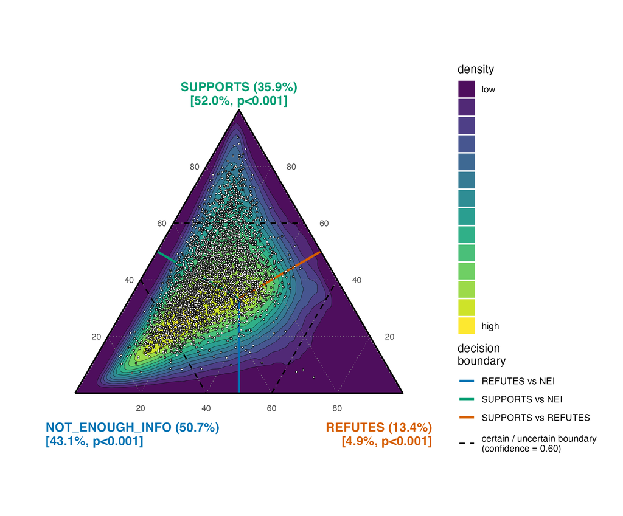

```r
if (!is.null(x$keypaper_summary)) {
  r <- x$keypaper_summary
  cat(sprintf(
    "**Key paper validation:** of **%d** key papers, **%.1f%%** landed in SUPPORTS\n\n",
    r$n, r$pct_supports
  ))
}
```

**Key paper validation:** of **3803** key papers, **52.0%** landed in SUPPORTS

## Claims and scores

Use the filter row below the header to narrow by KM, BM, claim, or label.

```r
x$widget
```

| km | bm | claim_id | claim | work | title | abstract | label | confidence | p_supports | p_refutes | p_nei | n_total_claim |
| --- | --- | --- | --- | --- | --- | --- | --- | --- | --- | --- | --- | --- |
| A. | A1 | bm_description-01 | For example, marine and freshwater-based food is co-produced by the combination of fish populations, fishing gear, and access to fishing grounds | 10.1093/jrs/fez081 | Institutionalization of a Formalized Intergovernmental Transfer Scheme for Asylum Seekers in Germany: TheKönigstein Keyas an Indicator of Federal Justice | Abstract Crisis-induced refugee migration raises questions of fair responsibility-sharing among political territories. This is relevant for nation states and for subnational territories alike. Theorie… | SUPPORTS | 0.896 | 0.896 | 0.046 | 0.057 | 23272 |
| A. | A1 | bm_description-01 | For example, marine and freshwater-based food is co-produced by the combination of fish populations, fishing gear, and access to fishing grounds | 10.1108/s1047-004220250000019007 | A School as a Common: How Community Participation Can Improve a Public Service and Transform It Into a Common | Abstract Commons can be understood as an organisational model based on relationships and social entanglements. These bonds primarily stem from the simultaneous actions of creating and governing the co… | REFUTES | 0.864 | 0.041 | 0.864 | 0.095 | 23272 |
| A. | A1 | bm_description-01 | For example, marine and freshwater-based food is co-produced by the combination of fish populations, fishing gear, and access to fishing grounds | 10.1080/23323256.2019.1639524 | Livelihoods fragility and land tenure in the post-fast track land reform era in Upper Guruve, Zimbabwe | This paper seeks to document the experiences of and challenges experienced by farmers resettled according to the communal/villagised model of resettlement in Upper Guruve district in Zimbabwe. The pap… | REFUTES | 0.862 | 0.081 | 0.862 | 0.057 | 23272 |
| A. | A1 | bm_description-01 | For example, marine and freshwater-based food is co-produced by the combination of fish populations, fishing gear, and access to fishing grounds | 10.1016/j.scitotenv.2019.134580 | Residential urban tree canopy is associated with decreased mortality during tuberculosis treatment in California |  | SUPPORTS | 0.853 | 0.853 | 0.068 | 0.079 | 23272 |
| A. | A1 | bm_description-01 | For example, marine and freshwater-based food is co-produced by the combination of fish populations, fishing gear, and access to fishing grounds | 10.1080/08941920.2011.578120 | Bridging Troubled Waters: Applying Consensus-Building Techniques to Water Planning | This research investigates a practical way to address clashes in stakeholder values and enhance outcomes in water allocation planning, in a case study of the water-stressed Lockyer catchment in Austra… | NOT_ENOUGH_INFO | 0.84 | 0.086 | 0.074 | 0.84 | 23272 |
| A. | A1 | bm_description-01 | For example, marine and freshwater-based food is co-produced by the combination of fish populations, fishing gear, and access to fishing grounds | 10.1111/j.1740-8784.2011.00279.x | Building a Knowledge-Driven Society: Scholar Participation and Governance in Large Public Works Projects | Previous studies have found no relationship between scholar participation and public project performance. Building on the work of Lindblom (1977; 1990), I propose a model depicting scholars' roles in … | NOT_ENOUGH_INFO | 0.83 | 0.106 | 0.064 | 0.83 | 23272 |
| A. | A1 | bm_description-01 | For example, marine and freshwater-based food is co-produced by the combination of fish populations, fishing gear, and access to fishing grounds | 10.1007/s41649-019-00076-4 | Linking Biodiversity with Health and Well-being: Consequences of Scientific Pluralism for Ethics, Values and Responsibilities |  | SUPPORTS | 0.827 | 0.827 | 0.081 | 0.092 | 23272 |
| A. | A1 | bm_description-01 | For example, marine and freshwater-based food is co-produced by the combination of fish populations, fishing gear, and access to fishing grounds | 10.1007/978-3-031-51837-9_11 | Children, Citizenship, and Commons: Insights from Three Case Studies in Lisbon on the 3 C's | Abstract Listening to children in educational settings is vital for establishing inclusive and equitable environments. This approach recognizes children as active agents and contributors to their educ… | REFUTES | 0.826 | 0.103 | 0.826 | 0.07 | 23272 |
| A. | A1 | bm_description-01 | For example, marine and freshwater-based food is co-produced by the combination of fish populations, fishing gear, and access to fishing grounds | 10.17645/up.v8i2.6597 | For a Cooperative “Smart” City Yet to Come: Place-Based Knowledge, Commons, and Prospects for Inclusive Municipal Processes From Seattle, Washington | This article explores possibilities for cooperative, equitable, and participatory forms of smart urbanism. We begin by outlining orientations that emphasize the heterogeneity of economic and urban lif… | REFUTES | 0.826 | 0.107 | 0.826 | 0.067 | 23272 |
| A. | A1 | bm_description-01 | For example, marine and freshwater-based food is co-produced by the combination of fish populations, fishing gear, and access to fishing grounds | 10.1017/9781139024297.014 | Seed Gene Bank Conservation | The objective of seed conservation is to preserve the genetic integrity of the seed under controlled conditions. For this, representative seed samples of the natural populations are stored, i.e., the … | REFUTES | 0.825 | 0.055 | 0.825 | 0.12 | 23272 |

[output cut: 10440 more lines]